# Estudis d'Informàtica, Multimedia i Telecomunicacions

# Tipologia i cicle de vida de les dades: PRACTICA2

Autor: Oriol Toll i Laura Gassó

May 2022

# 1 Introducció

Aquest projecte pretén posar en pràctica les activitats que es duen a terme en les fases inicials d’un projecte de mineria de dades. Aquestes tenen com a objectiu obtenir un domini de les dades amb les que es construirà el model de mineria. És vital coneixer profundament les dades tant en el seu format com contingut. Tasques típiques poden ser la selecció de característiques o variables, la preparació del joc de dades per a posteriorment ser consumit per un algorisme (tractament de valors nuls i outliers, transformacions, codificació de les variables categòriques, etc) i intentar extreure el màxim coneixement possible de les dades.

Per a la resolució d’aquest projecte es farà ús del dataset de **Titànic** obtingut de la pàgina de kaggle: https://www.kaggle.com/competitions/titanic/data

# 2 Resolució

S’instal·len i es carreguen les llibreries

```r
# Set libraries
library(data.table)
library(tidyr)
# https://cran.r-project.org/web/packages/arules/index.html
if (!require('arules')) install.packages('arules'); library('arules')
# https://cran.r-project.org/web/packages/ggplot2/index.html
if (!require('ggplot2')) install.packages('ggplot2'); library('ggplot2')
# https://cran.r-project.org/web/packages/dplyr/index.html
if (!require('dplyr')) install.packages('dplyr'); library('dplyr')
if (!require("DT")) install.packages('DT'); library('DT')
if (!require("nortest")) install.packages('nortest'); library('nortest')
if (!require("dplyr")) install.packages('dplyr'); library('dplyr')
```

Es carreguen els fitxers de dades.

```r
# Load data
raw.train <- data.table::fread("./data/train.csv", dec = ".")
raw.test <- data.table::fread("./data/test.csv", dec = ".")
```

## 2.1 Quina pregunta/problema es pot respondre amb el dataset Titànic?

El dataset Titànic representa informació sobre els passatgers i la tripulació que anava en el Titànic en el moment del naufràgi. A partir de l’anàlisi dels supervivents i els morts en aquest accident, es poden compèndre els critèris i procediments d’evacuació que es van dur a terme en el moment del sinistre.

També es pot utilizar el dataset per tal de crear un algoritme de classificació que ajudi a a predir la probabilitat de salvar-se d’un passatger.

## 2.2 Exploració de les dades i descripció del dataset

S’uneix el joc de dades de train i test per tal de realitzar les tasques de neteja i processament.

```r
# Get full dataset

# Check if any label on training is missing
if(sum(is.na(raw.train$Survived)) == 0) {

  # Join train and test set
  test <- raw.test[, Survived := NA]
  total.data <- rbind(raw.train, test)
} else {
  print('There are some missing values in dependant variable on training data set')
}
```

Es verifica l’estructura del joc de dades principal.

```r
str(total.data)
```

```
## Classes 'data.table' and 'data.frame':   1309 obs. of  12 variables:
##  $ PassengerId: int  1 2 3 4 5 6 7 8 9 10 ...
##  $ Survived   : int  0 1 1 1 0 0 0 0 1 1 ...
##  $ Pclass     : int  3 1 3 1 3 3 1 3 3 2 ...
##  $ Name       : chr  "Braund, Mr. Owen Harris" "Cumings, Mrs. John Bradley (Florence Briggs Thayer)" "Heikkinen, Miss. Laina" "Futrelle, Mrs. Jacques Heath (Lily May Peel)" ...
##  $ Sex        : chr  "male" "female" "female" "female" ...
##  $ Age        : num  22 38 26 35 35 NA 54 2 27 14 ...
##  $ SibSp      : int  1 1 0 1 0 0 0 3 0 1 ...
##  $ Parch      : int  0 0 0 0 0 0 0 1 2 0 ...
##  $ Ticket     : chr  "A/5 21171" "PC 17599" "STON/O2. 3101282" "113803" ...
##  $ Fare       : num  7.25 71.28 7.92 53.1 8.05 ...
##  $ Cabin      : chr  "" "C85" "" "C123" ...
##  $ Embarked   : chr  "S" "C" "S" "S" ...
##  - attr(*, ".internal.selfref")=<externalptr>
```

S’observa que es tenen 1309 registres que corresponen als viatgers i tripulació del Titànic i 11 variables que els caracteritzen.

Es revisa la descripció de les variables contingudes al fitxer i si els tipus de variable es correspon al que s’ha carregat:

**PassengerId** integer with the id of the row (one for each passenger)

**Survived** a factor with two levels (no and yes) specifying whether the person has survived the sinking.

**Pclass** factor specifying the class for passengers or the type of service aboard for crew members.

**Name** string with the name of the passenger.

**Sex** factor with levels male and female.

**Age** numeric value with the persons age on the day of the sinking. The age of babies (under 12 months) is given as a fraction of one year (1/month).

**SibSp** ordered factor specifying the number if siblings/spouses aboard; adopted from Vanderbild data set.

**Parch** an ordered factor specifying the number of parents/children aboard; adopted from Vanderbild data set.

**Ticket** string specifying the persons ticket number (NA for crew members).

**Fare** numeric value with the ticket price (NA for crew members, musicians and employees of the shipyard company).

**Cabin** string specifying the persons cabin

**Embarked** factor with the persons place of embarkment.

Es canvien a factor les columnes necessaries.

```r
changeCols <- c('Survived', 'Pclass', 'Sex', 'SibSp', 'Parch')
total.data[,(changeCols):= lapply(.SD, as.factor), .SDcols = changeCols]
```

Es treuen les estadístiques bàsiques.

```r
# Get data summary
summary(total.data)
```

```
##   PassengerId   Survived   Pclass      Name               Sex
##  Min.   :   1   0   :549   1:323   Length:1309        female:466
##  1st Qu.: 328   1   :342   2:277   Class :character   male  :843
##  Median : 655   NA's:418   3:709   Mode  :character
##  Mean   : 655
##  3rd Qu.: 982
##  Max.   :1309
##
##       Age        SibSp       Parch         Ticket               Fare
##  Min.   : 0.17   0:891   0      :1002   Length:1309        Min.   :  0.000
##  1st Qu.:21.00   1:319   1      : 170   Class :character   1st Qu.:  7.896
##  Median :28.00   2: 42   2      : 113   Mode  :character   Median : 14.454
##  Mean   :29.88   3: 20   3      :   8                      Mean   : 33.295
##  3rd Qu.:39.00   4: 22   4      :   6                      3rd Qu.: 31.275
##  Max.   :80.00   5:  6   5      :   6                      Max.   :512.329
##  NA's   :263     8:  9   (Other):   4                      NA's   :1
##     Cabin             Embarked
##  Length:1309        Length:1309
##  Class :character   Class :character
##  Mode  :character   Mode  :character
##
##
##
##
```

S’observa que els passatgers eren molt joves donat que la mitjana d’edat és 29.88.

## 2.3 Integració i selecció de les dades d’interès a analitzar

Les dades que s’utlitzaran són les que anteriorment s’han ajuntat del data de **test** i el de **train.** Tot i això, no s’estudiaran ni tractaran totes les variables, donat que variables com *PassengerID*, *Name*, *Cabin* o *Ticket*, ens aporten informació que no serà de cap utilitat per resoldre el problema incial.

```r
work.data <- total.data[,.(Survived, Pclass, Sex, Age, SibSp, Parch, Fare, Embarked)]
```

## 2.4 Neteja de les dades.

### 2.4.1 Estadístiques de valors buits.

```r
colSums(is.na(work.data))
```

```
## Survived   Pclass      Sex      Age    SibSp    Parch     Fare Embarked
##      418        0        0      263        0        0        1        0
```

```r
colSums(work.data=="")
```

```
## Survived   Pclass      Sex      Age    SibSp    Parch     Fare Embarked
##       NA        0        0       NA        0        0       NA        2
```

Assignem la mitjana per a valors buits de la variable *Age*.

```r
work.data$Age[is.na(work.data$Age)] <- mean(work.data$Age,na.rm=T)
```

Assignem un valor de **0** al valor buit de la variable *Fare*, ja que correspon al preu del tiquet d’un membre de la tripulació.

```r
work.data$Fare[is.na(work.data$Fare)] <- 0
```

Assignem valor **Desconegut** per a valors buits de la variable *Embarked*.

```r
work.data$Embarked[(work.data$Embarked == "")] <- "Desconegut"
```

## 2.5 Anàlisi de les dades.

Per començar, es farà una representació gràfica per les variables que es volen analitzar, d’aquesta manera, es podrà tenir una idea principal de com es comporten totes elles:

### 2.5.1 Visualització dades numèriques

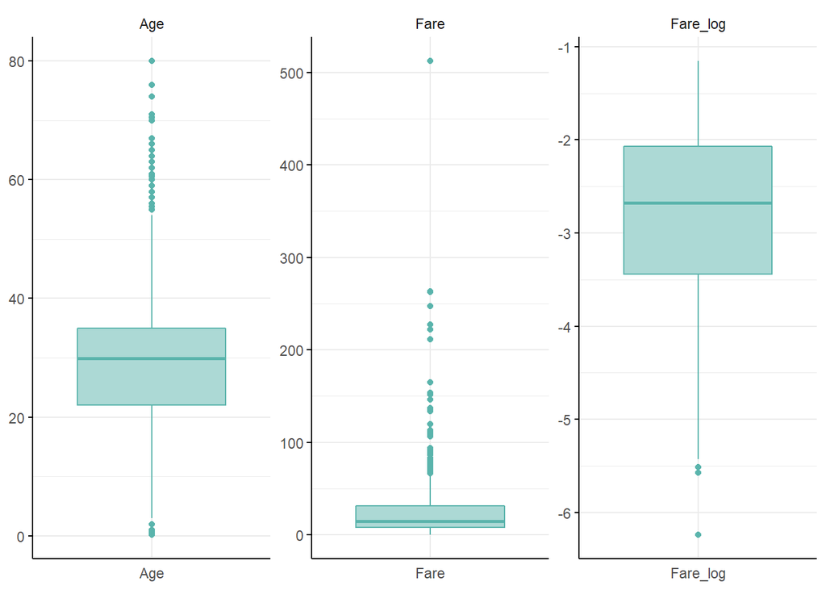

```r
work.data$Fare_log <- -log(work.data$Fare)

meltData <- melt(work.data[, .(Age, Fare, Fare_log)])
p <- ggplot(meltData, aes(factor(variable), value))
p + geom_boxplot(fill="#ACD9D5", color = "#5AB4AC") +
  facet_wrap(~variable, scale="free") +
  theme_minimal() +
  theme(axis.title.x = element_blank(),
        axis.title.y = element_blank()) +
  theme(axis.line = element_line(colour = "black"), axis.text.y = element_text(hjust = 1),
        axis.ticks.y = element_line(colour = "black"))
```

En el boxplot sense transformar de la variable Fare, no es pot apreciar res a causa de les observacions amb valors elevats. Es procedeix per tant a aplicar el logaritme a la variable per tal de poder visualitzar millor els resultats.

Pel que fa als valors extrems que es poden veure al gràfic, pertanyen a 4 passatgers amb un preu del tiquet de 512, molt més elevat que els de la resta, però com hem pogut comprobar, tots 4 pertanyen al grup de classe alta de l’embaració. Per tant, poden tranquilament pertnayer a valors reals del preu del bitllet i no es farà cap mena de tractament.

```r
extrems <- work.data[work.data$Fare==max(work.data$Fare)]
print(extrems)
```

```
##    Survived Pclass    Sex Age SibSp Parch     Fare Embarked  Fare_log
## 1:        1      1 female  35     0     0 512.3292        C -6.238967
## 2:        1      1   male  36     0     1 512.3292        C -6.238967
## 3:        1      1   male  35     0     0 512.3292        C -6.238967
## 4:     <NA>      1 female  58     0     1 512.3292        C -6.238967
```

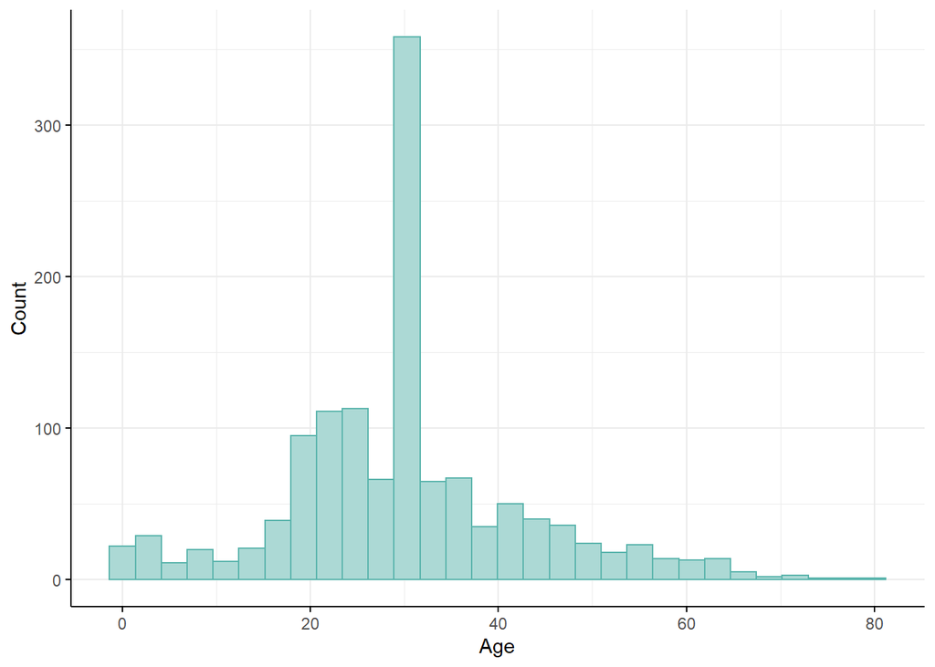

```r
plot <- ggplot(work.data, aes(x=work.data$Age))
plot + geom_histogram(fill = "#ACD9D5", color = "#5AB4AC") +
  theme_minimal() +
    theme(axis.line = element_line(colour = "black"), axis.text.y = element_text(hjust = 1),
        axis.ticks = element_line(colour = "black")) +
  labs(x = "Age", y = "Count")
```

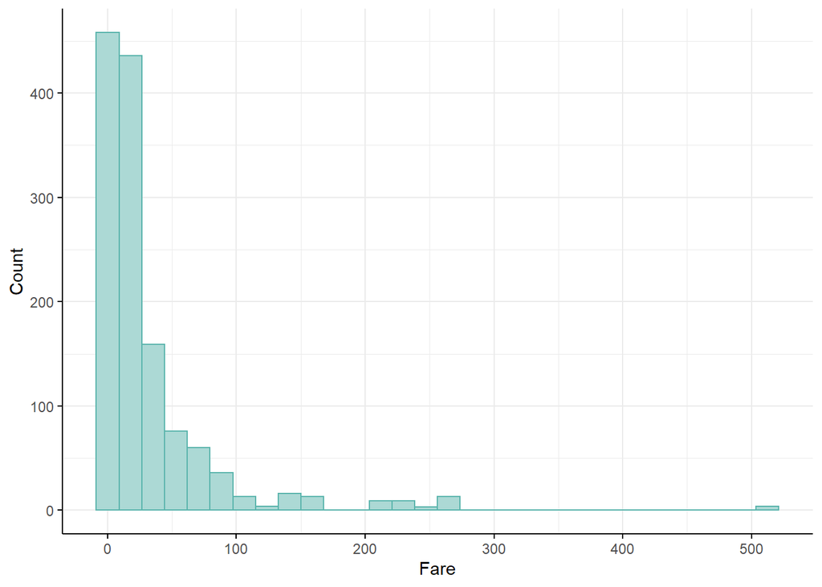

```r
plot <- ggplot(work.data, aes(x=work.data$Fare))
plot + geom_histogram(fill = "#ACD9D5", color = "#5AB4AC") +
  theme_minimal() +
    theme(axis.line = element_line(colour = "black"), axis.text.y = element_text(hjust = 1),
        axis.ticks = element_line(colour = "black")) +
  labs(x = "Fare", y = "Count")
```

A partir de l’histograma s’observa que la variable *Fare* no segueix una distribució normal, però la vairbale *Age* s’haurà d’analitzar més endavant per comprobar-ho.

### 2.5.2 Visualització dades categòriques

- *Survived:*

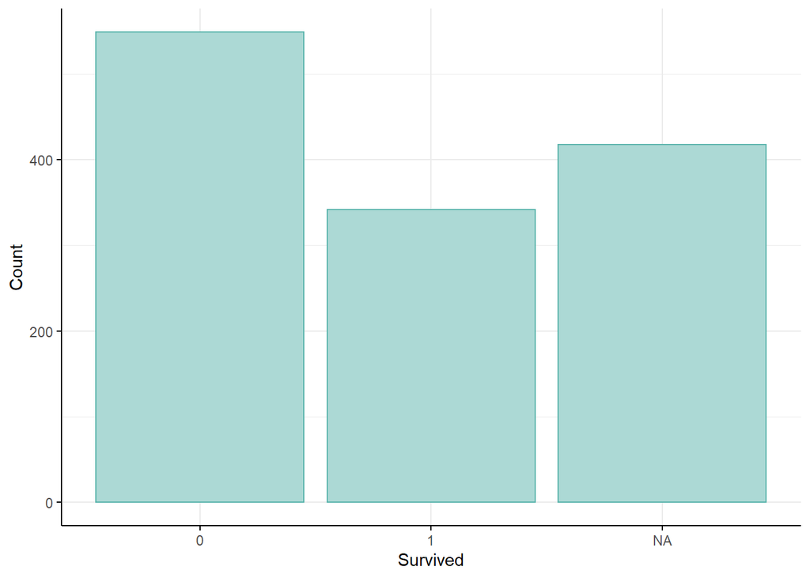

```r
ggplot(work.data, aes(x=work.data$Survived)) +
  geom_bar(xlab = "Survived", fill = "#ACD9D5", color = "#5AB4AC") +
  theme_minimal() +
  theme(axis.line = element_line(colour = "black"), axis.text.y = element_text(hjust = 1),
        axis.ticks = element_line(colour = "black")) +
  labs(x = "Survived", y = "Count")
```

- *Pclass:*

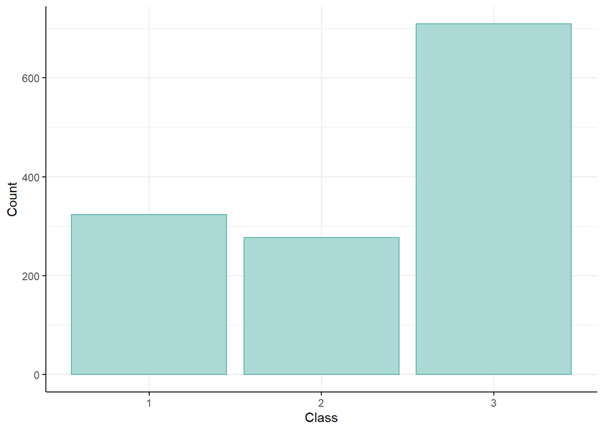

```r
ggplot(work.data, aes(x=work.data$Pclass)) +
  geom_bar(xlab = "Pclass", fill = "#ACD9D5", color = "#5AB4AC") +
  theme_minimal() +
  theme(axis.line = element_line(colour = "black"), axis.text.y = element_text(hjust = 1),
        axis.ticks = element_line(colour = "black")) +
  labs(x = "Class", y = "Count")
```

- *Sex:*

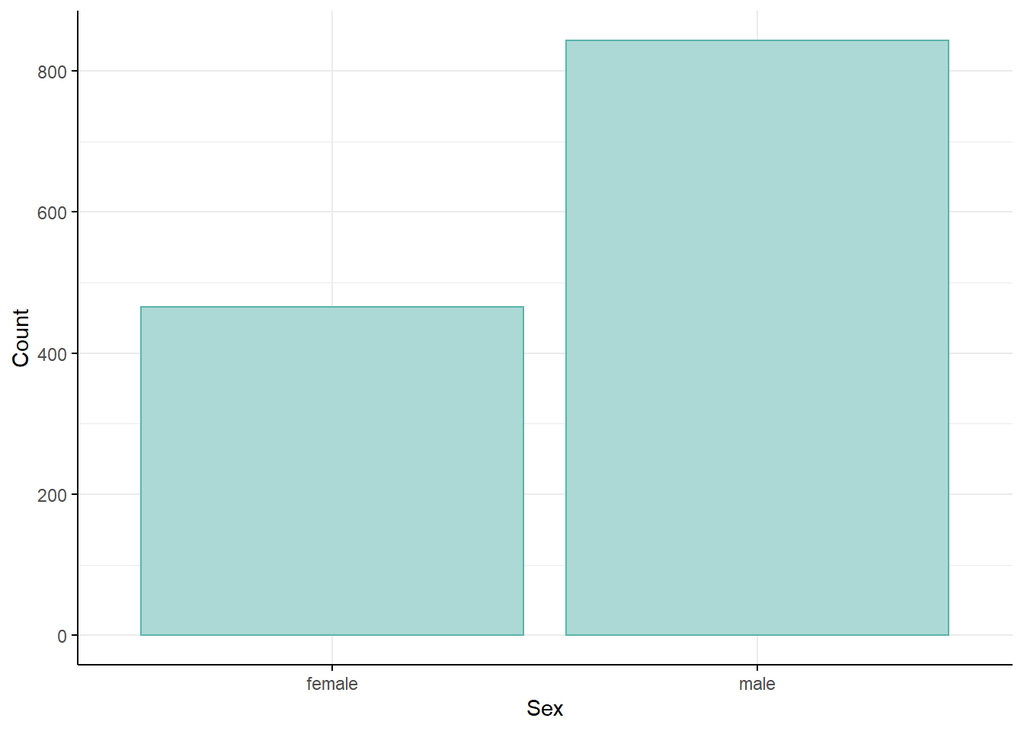

```r
ggplot(work.data, aes(x=work.data$Sex)) +
  geom_bar(xlab = "Sex", fill = "#ACD9D5", color = "#5AB4AC") +
  theme_minimal() +
  theme(axis.line = element_line(colour = "black"), axis.text.y = element_text(hjust = 1),
        axis.ticks = element_line(colour = "black")) +
  labs(x = "Sex", y = "Count")
```

- *Embarked:*

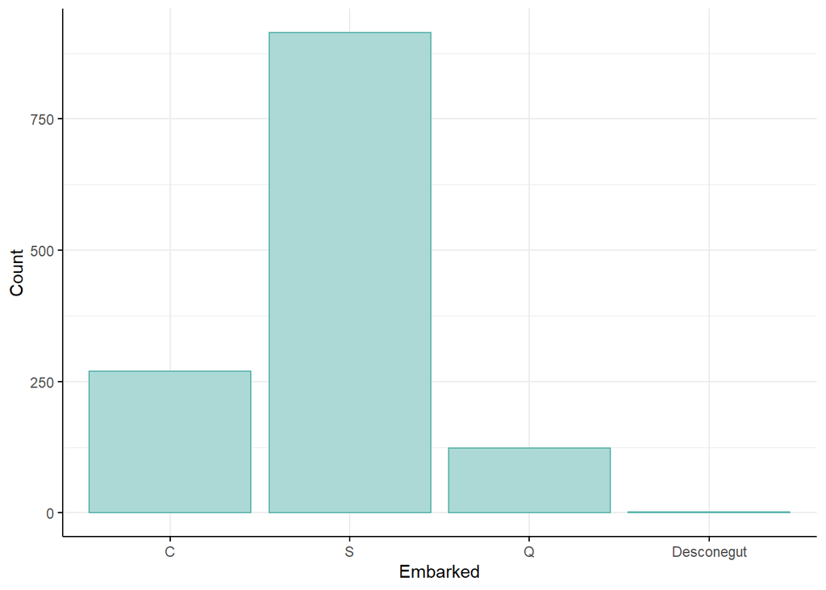

```r
ggplot(work.data, aes(x = factor(work.data$Embarked, level = c("C", "S", "Q", "Desconegut")))) +
  geom_bar(xlab = "Embarked", fill = "#ACD9D5", color = "#5AB4AC") +
  theme_minimal() +
  theme(axis.line = element_line(colour = "black"), axis.text.y = element_text(hjust = 1),
        axis.ticks = element_line(colour = "black")) +
  labs(x = "Embarked", y = "Count")
```

- *SibSp:*

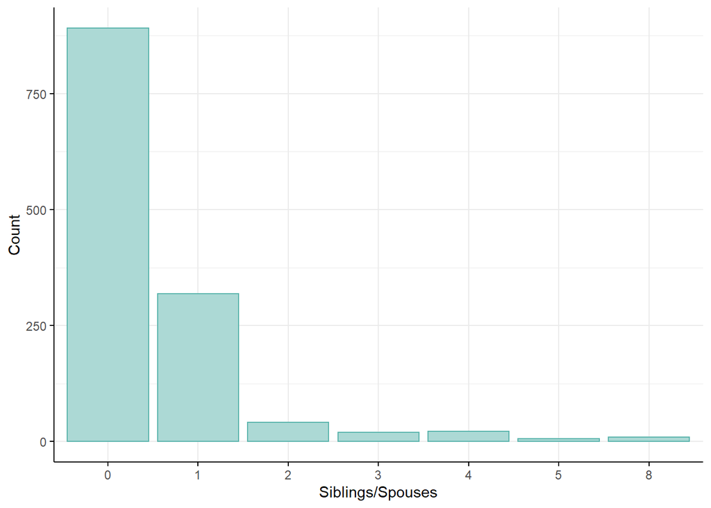

```r
ggplot(work.data, aes(x=work.data$SibSp)) +
  geom_bar(xlab = "SibSp", fill = "#ACD9D5", color = "#5AB4AC") +
  theme_minimal() +
  theme(axis.line = element_line(colour = "black"), axis.text.y = element_text(hjust = 1),
        axis.ticks = element_line(colour = "black")) +
  labs(x = "Siblings/Spouses", y = "Count")
```

- *Parch:*

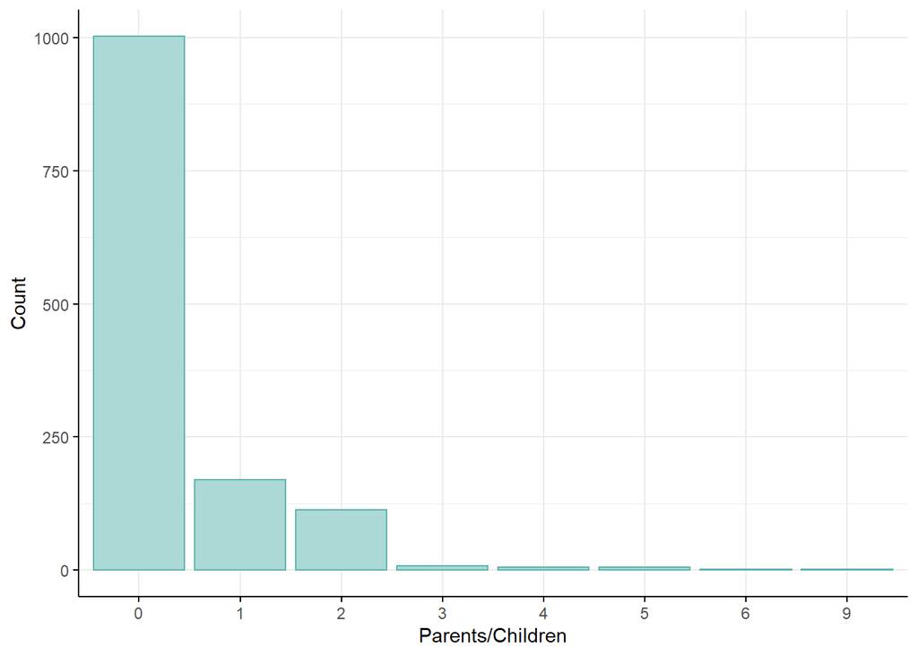

```r
ggplot(work.data, aes(x=work.data$Parch)) +
  geom_bar(xlab = "Parch", fill = "#ACD9D5", color = "#5AB4AC") +
  theme_minimal() +
  theme(axis.line = element_line(colour = "black"), axis.text.y = element_text(hjust = 1),
        axis.ticks = element_line(colour = "black")) +
  labs(x = "Parents/Children", y = "Count")
```

### 2.5.3 Selecció dels grups de dades que es volen analitzar/comparar

Un cop netejat el dataset, es torna a dividir en train i test per tal de realitzar els anàlisis.

```r
work.train <- work.data[!is.na(Survived)]
work.test <- work.data[is.na(Survived)]
```

A partir d’aqui es procedeix a anàlitzar si els factors classe i genere són rellevants per a la supervivència.

Es procedeix a analitzar les relacions entre les diferents variables del joc de dades per veure si es relacionen i com es comporten entre elles.

Es visualitza la relació entre les variables *sex* i *survived*:

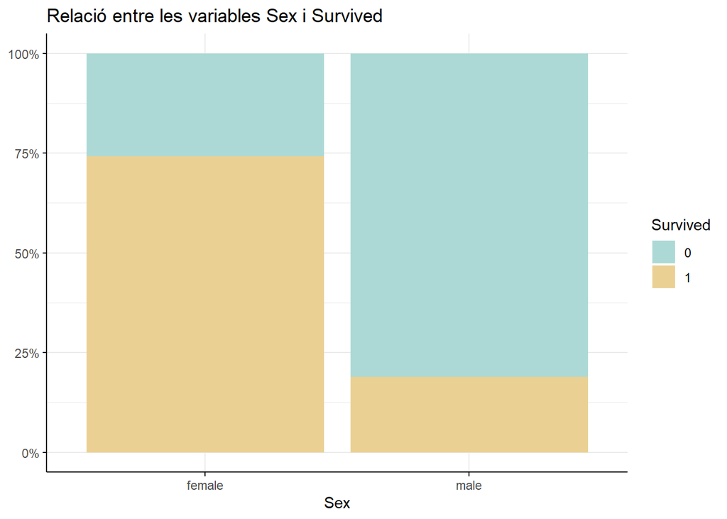

```r
ggplot(work.train) +
  geom_bar(aes(Sex, fill = Survived), position = "fill") +
  ggtitle("Relació entre les variables Sex i Survived") +
  theme_minimal() +
  theme(axis.title.y = element_blank()) +
  theme(axis.line = element_line(colour = "black"), axis.text.y = element_text(hjust = 1),
        axis.ticks = element_line(colour = "black"))  +
  scale_fill_manual(values = c("0" = "#ACD9D5", "1" = "#EAD093")) +
  scale_y_continuous(labels = c("0%", "25%", "50%", "75%", "100%"),
                     breaks = c(0, 0.25, 0.50, 0.75, 1.00))
```

Es visualitza la relació entre les variables *pclass* i *survived*:

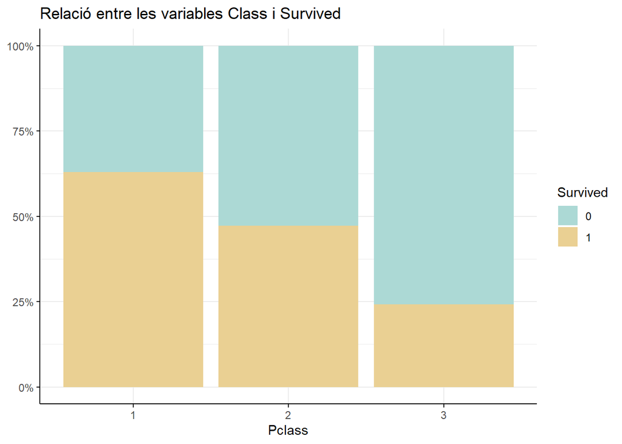

```r
ggplot(work.train) +
  geom_bar(aes(Pclass, fill = Survived), position = "fill") +
  ggtitle("Relació entre les variables Class i Survived") +
  theme_minimal() +
  theme(axis.title.y = element_blank()) +
  theme(axis.line = element_line(colour = "black"), axis.text.y = element_text(hjust = 1),
        axis.ticks = element_line(colour = "black"))  +
  scale_fill_manual(values = c("0" = "#ACD9D5", "1" = "#EAD093")) +
  scale_y_continuous(labels = c("0%", "25%", "50%", "75%", "100%"),
                     breaks = c(0, 0.25, 0.50, 0.75, 1.00))
```

Es visualitza la relació entre la combinació de les variables *pclass* i *sex* amb la variable *survived*:

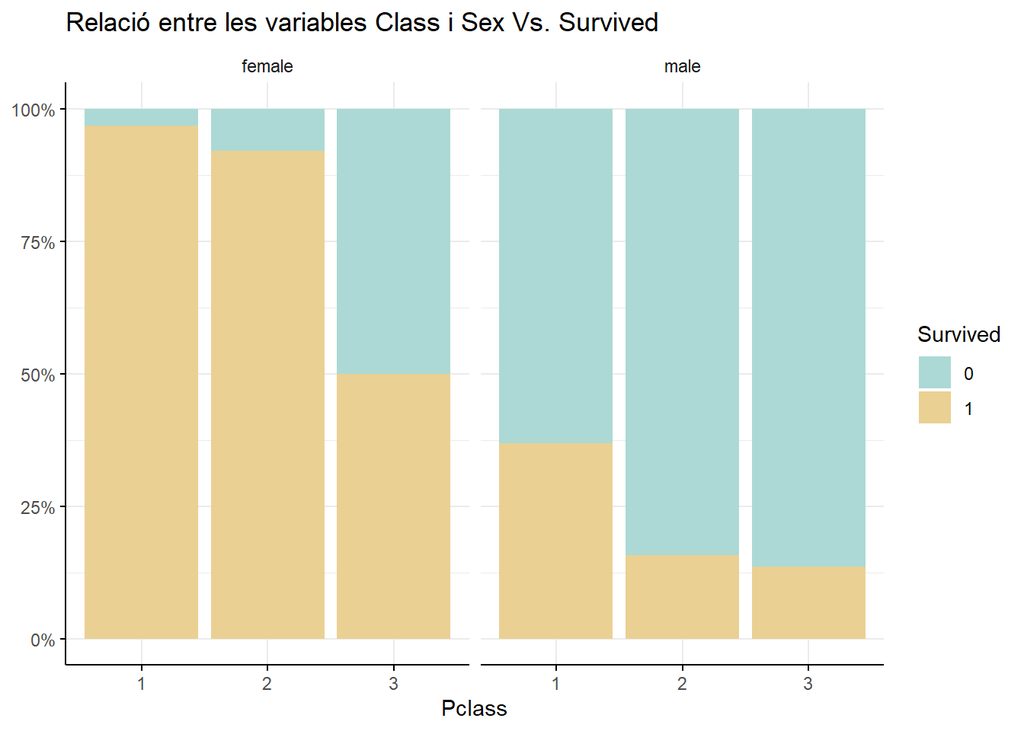

```r
ggplot(work.train) +
  geom_bar(aes(Pclass, fill = Survived), position = "fill") + facet_wrap(~Sex) +
  ggtitle("Relació entre les variables Class i Sex Vs. Survived") +
  theme_minimal() +
  theme(axis.title.y = element_blank()) +
  theme(axis.line = element_line(colour = "black"), axis.text.y = element_text(hjust = 1),
        axis.ticks = element_line(colour = "black"))  +
  scale_fill_manual(values = c("0" = "#ACD9D5", "1" = "#EAD093")) +
  scale_y_continuous(labels = c("0%", "25%", "50%", "75%", "100%"),
                     breaks = c(0, 0.25, 0.50, 0.75, 1.00))
```

Tal i com es pot observar en els gràfics si que sembla que hi hagi una correlació entre la classe o el gènere i el fet de sobreviure. A priori sembla que les dones i les classes altes tenen un rati de supervivència més elevat.

### 2.5.4 Comprovació de la normalitat i homogeneïtat de la variància.

- *Age:*

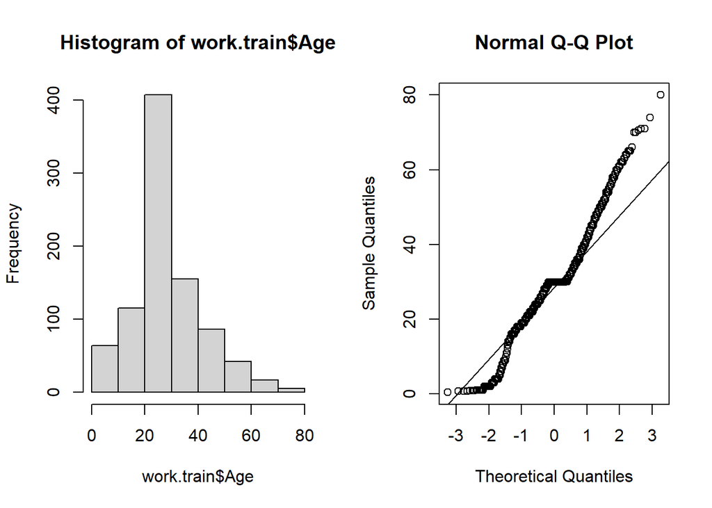

```r
#Gràfics
par(mfrow=c(1,2))
hist(work.train$Age) # histograma
qqnorm(work.train$Age) # gràfic quantile
qqline(work.train$Age)
```

```r
#Contrast de normalitat
shapiro.test(work.train$Age) #contrast
```

```
##
##  Shapiro-Wilk normality test
##
## data:  work.train$Age
## W = 0.95921, p-value = 4.773e-15
```

Com es pot observar en els gràfics i en el contrast d’hipótesis, no podem afirmar amb un nivell de significació del 5% que aquesta variable segueix una distribució Normal, ja que el p_valor resultant és inferior a 0,05.

- *Fare:*

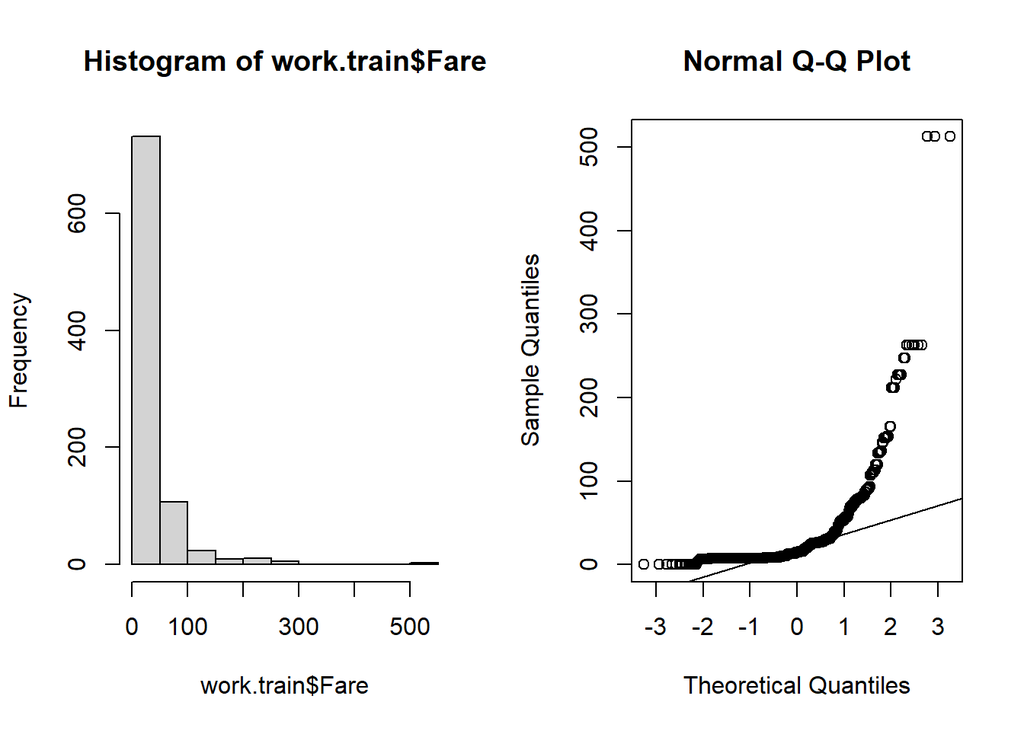

```r
#Gràfics
par(mfrow=c(1,2))
hist(work.train$Fare) # histograma
qqnorm(work.train$Fare) # gràfic quantile
qqline(work.train$Fare)
```

```r
#Contrast de normalitat
shapiro.test(work.train$Fare) #contrast
```

```
##
##  Shapiro-Wilk normality test
##
## data:  work.train$Fare
## W = 0.52189, p-value < 2.2e-16
```

De la mateixa manera que amb *Age* i amb els gràfics que haviem vist anteriorment, no podem afirmar amb un nivell de significació del 5% que aquesta variable segueix una distribució Normal, ja que el p_valor resultant és inferior a 0,05.

### 2.5.5 Aplicació de proves estadístiques per comparar els grups de dades

#### 2.5.5.1 Variables numériques Vs. Supervivéncia

Com en el cas del nostre conjunt de dades, les variables numériques, no segueixen una Normal, s’haurà de fer proves no paramètriques per comparar diferents grups de dades, com per exemple la prova de Mann-Withney o la de Wilocxon.

- La primera comparació que durem a terme, serà entre les variables *Age* i *Survived*

```r
# Es pot fer un gràfic d'edat vs survived
wilcox.test(Age ~ Survived, data = work.train)
```

```
##
##  Wilcoxon rank sum test with continuity correction
##
## data:  Age by Survived
## W = 98220, p-value = 0.2434
## alternative hypothesis: true location shift is not equal to 0
```

Gràcies al contrast d’hipótesis, no podem observar diferències estadístiques entre les persones que van sobreviure i les que no segons la seva edat.

- La següent comparació serà entre les variables *Fare* i *Survived*

```r
# Es pot fer un gràfic de preu vs survived
wilcox.test(Fare ~ Survived, data = work.train)
```

```
##
##  Wilcoxon rank sum test with continuity correction
##
## data:  Fare by Survived
## W = 57807, p-value < 2.2e-16
## alternative hypothesis: true location shift is not equal to 0
```

En aquest cas, gràcies al contrast d’hipótesis, sí que podem observar diferències estadístiques entre les persones que van sobreviure i les que no en funció del preu del seu bitllet.

#### 2.5.5.2 Variables discretes Vs. Supervivència

En el cas de les comparacions entre dues variables categòriques, una d’elles amb dos grups, el que farem serà per cada una d’elles crear una taula de freqüències creuant les dues variables. I amb la taula resultant, fer una proba $\chi^2$ i veure si hi ha diferències estadístiques suficients per dir que els dos grups són diferents.

- Comparació entre *Pclass* i *Survived*

```r
chisq_classe <- table(work.train$Survived, work.train$Pclass)
chisq.test(chisq_classe)
```

```
##
##  Pearson's Chi-squared test
##
## data:  chisq_classe
## X-squared = 102.89, df = 2, p-value < 2.2e-16
```

Com es veu en el resultat del test, p_valor inferior a 0,05, podem dir que hi ha diferències entre els supervivents i els morts segons la seva classe.

- Comparació entre *Sex* i *Survived*

```r
chisq_sexe <- table(work.train$Survived, work.train$Sex)
chisq.test(chisq_sexe)
```

```
##
##  Pearson's Chi-squared test with Yates' continuity correction
##
## data:  chisq_sexe
## X-squared = 260.72, df = 1, p-value < 2.2e-16
```

Com es veu en el resultat del test, p_valor inferior a 0,05, podem dir que hi ha diferències entre els supervivents i els morts segons el seu sexe.

- Comparació entre *SibSp* i *Survived*

Com que la variable *SibSp* consta de 7 categories, el contrast de la prova $\chi$ tindrà 6 graus de llibertat. Per tant, s’ha d’anar en compte a l’hora de llegir els resultats, ja que pot haver-hi errors d’aproximació en el test.

```r
chisq_sibsp <- table(work.train$Survived, work.train$SibSp)
chisq.test(chisq_sibsp)
```

```
##
##  Pearson's Chi-squared test
##
## data:  chisq_sibsp
## X-squared = 37.272, df = 6, p-value = 1.559e-06
```

Com es veu en el resultat del test, p_valor inferior a 0,05, podem dir que hi ha diferències entre els supervivents i els morts segons el nombre de germans o cònjugues amb els que van embarcar.

- Comparació entre *Parch* i *Survived*

```r
chisq_parch <- table(work.train$Survived, work.train$Parch)
chisq.test(chisq_parch)
```

```
##
##  Pearson's Chi-squared test
##
## data:  chisq_parch
## X-squared = NaN, df = 7, p-value = NA
```

## 2.6 Model

Es procedeix a aplicar un GLM com a model de classificació per poder predir la probabilitat de supervivència.

```r
changeCols <- c('Survived')
work.train[,(changeCols):= lapply(.SD, as.character), .SDcols = changeCols]
work.train[,(changeCols):= lapply(.SD, as.numeric), .SDcols = changeCols]
```

### 2.6.1 Entrenant el model amb Edat i Sexe

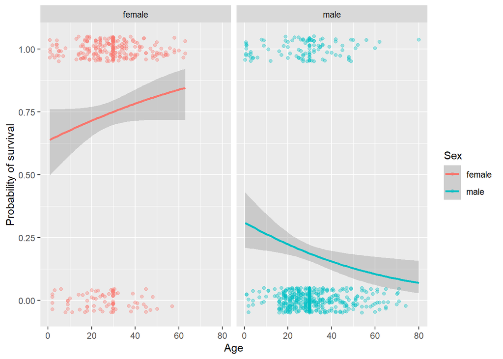

```r
work.train %>%
   ggplot(aes(x = Age, y = Survived, color = Sex)) +
   geom_jitter(height = 0.05, alpha = 0.35) +
   geom_smooth(method="glm", method.args = list(family="binomial"))  +
   facet_wrap(~Sex) +
   labs(x = "Age", y = "Probability of survival")
```

Interpretant les dades a partir de la variable sexe s’observa com el criteri de “nenes primer” sembla cert únicament per als homes.

### 2.6.2 Entrenant el model amb Edat, Sexe i Classe

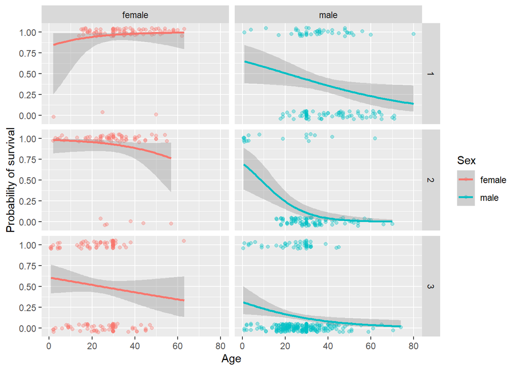

```r
work.train %>%
   ggplot(aes(x = Age, y = Survived, color = Sex)) +
   geom_jitter(height = 0.05, alpha = 0.35) +
   geom_smooth(method="glm", method.args = list(family="binomial"))  +
   facet_grid(Pclass~Sex) +
   labs(x = "Age", y = "Probability of survival")
```

Al afegir la variable classe al model s’obté encara més informació sobre les dades i les conclusions anteriors poden canviar.

- S’observa com les passatgeres femenines de primera classe sobreviuen gairebé totes i per tant l’edat no juga un paper important aqui (la relació entre edat i supervivència per a aquest grup és plana).
- Les passetgeres de 2a classe té un comportament similar al de la 1a amb una lleugera disminució de la probabilitat de supervivència per a les passetgeres més grans.
- Per a les passetgeres de 3a claase s’observa la regla de “els nens primer”.
- Per als passetgers masculins, el criteri “nens primer” sembla adaptar-se en totes les classes tot i que la probabilitat de supervivència és més alta com més lata és la classe.

## 2.8 Taula de contribucions

|  | Contribucions | Firma |
| --- | --- | --- |
| 1 | Investigació previa | Oriol Toll, Laura Gassó |
| 2 | Redacció de les respostes | Oriol Toll, Laura Gassó |
| 3 | Desenvolupament del codi | Oriol Toll, Laura Gassó |